# Informe Técnico y Metodológico

Evolución semestral de actividades estratégicas y analíticas para el crecimiento del Almacen Nancy.com

JOHN JAIRO PRADO PIÑERES

2026-05-26

[output not shown]

# **Introducción**

El presente informe describe la evolución semestral de las actividades estratégicas, operativas y analíticas desarrolladas en Almacén Nancy.com durante el periodo comprendido entre el 1 de febrero de 2021 y el 28 de febrero de 2025.

El proceso estuvo orientado al fortalecimiento del negocio mediante metodologías de análisis de datos, estadística aplicada, monitoreo comercial, control operativo y soporte estratégico para la toma de decisiones.

Por criterios de confidencialidad y protección de información estratégica de la organización, no se presentan datos financieros absolutos ni métricas sensibles. No obstante, se describen los principales procesos implementados, resultados obtenidos e impactos organizacionales alcanzados durante el periodo evaluado.

# Resumen metodológico

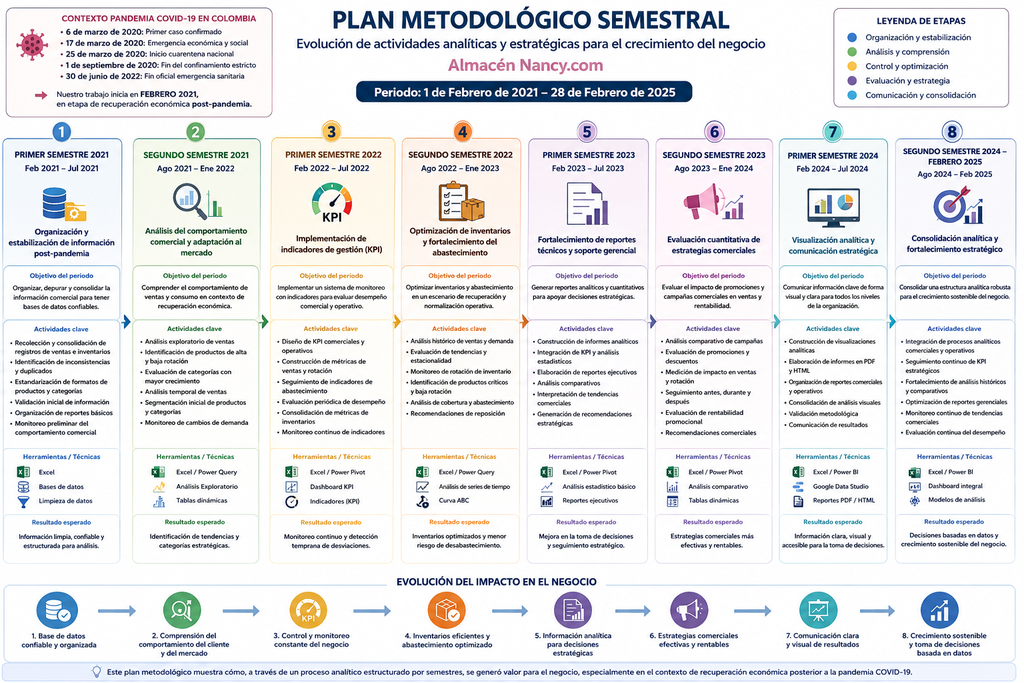

# **Contexto post-pandemia COVID-19**

La experiencia laboral desarrollada se llevó a cabo en un escenario de recuperación económica posterior a la pandemia COVID-19, caracterizado por:

- cambios en patrones de consumo,
- variabilidad en la demanda,
- fluctuaciones comerciales,
- ajustes en abastecimiento e inventarios,
- necesidad de fortalecer procesos analíticos y operativos.

En respuesta a este contexto, la organización fortaleció procesos relacionados con:

- calidad y validación de datos,
- análisis estadístico,
- monitoreo de KPI,
- análisis histórico de ventas,
- evaluación de estrategias comerciales,
- generación de reportes técnicos.

# Primer semestre 2021

## **Febrero 2021 – Julio 2021**

### **Etapa**

Estabilización operativa y reorganización comercial en contexto post-pandemia.

### **Descripción**

Durante este periodo inicial, la organización enfrentó efectos derivados del contexto de recuperación económica posterior a la pandemia COVID-19, caracterizados por cambios en el comportamiento de consumo, variaciones en la demanda y ajustes operativos relacionados con abastecimiento e inventarios.

En respuesta a este escenario, se desarrollaron actividades orientadas a organizar, depurar y consolidar la información comercial y operativa para fortalecer la capacidad de monitoreo y análisis del negocio.

### **Actividades realizadas**

- Recolección y consolidación de registros históricos de ventas e inventarios.
- Identificación de inconsistencias en bases de datos comerciales.
- Estandarización de formatos de productos, categorías y registros operativos.
- Eliminación de duplicados y validación inicial de información.
- Organización de reportes básicos de ventas y abastecimiento.
- Monitoreo preliminar del comportamiento comercial en contexto post-pandemia.
- Seguimiento de variaciones de demanda en categorías estratégicas.

### **Impacto en el negocio**

- Mejora en la calidad y confiabilidad de la información.
- Mayor control sobre registros comerciales y operativos.
- Reducción de inconsistencias administrativas.
- Fortalecimiento de la capacidad de monitoreo comercial.
- Mejor adaptación operativa frente a cambios de demanda.

# **Segundo semestre 2021**

## **Agosto 2021 – Enero 2022**

### **Etapa**

Análisis del comportamiento comercial y adaptación al mercado.

### **Descripción**

Durante este periodo se fortalecieron procesos de análisis estadístico orientados a comprender el comportamiento de ventas y consumo en un entorno de recuperación económica y cambios de hábitos de compra posteriores a la pandemia.

### **Actividades realizadas**

- Desarrollo de análisis exploratorios de ventas.
- Identificación de productos de alta y baja rotación.
- Evaluación de categorías con mayor crecimiento comercial.
- Análisis temporal de comportamiento de ventas.
- Segmentación inicial de productos y categorías.
- Monitoreo de cambios de demanda asociados al contexto post-pandemia.
- Evaluación de tendencias de consumo y comportamiento comercial.

### **Impacto en el negocio**

- Identificación de categorías estratégicas para el negocio.
- Mejora en decisiones relacionadas con compras y abastecimiento.
- Optimización inicial del control de inventarios.
- Mayor comprensión del comportamiento del consumidor.
- Fortalecimiento de la capacidad de respuesta frente a cambios comerciales.

# **Primer semestre 2022**

## **Febrero 2022 – Julio 2022**

### **Etapa**

Implementación de indicadores de gestión y fortalecimiento operativo.

### **Descripción**

Durante esta etapa se estructuró un sistema de monitoreo mediante indicadores cuantitativos para evaluar desempeño comercial y operativo en un contexto donde aún persistían efectos económicos y logísticos derivados de la pandemia COVID-19.

### **Actividades realizadas**

- Diseño de KPI comerciales y operativos.
- Construcción de métricas de ventas y rotación.
- Seguimiento de indicadores de abastecimiento.
- Evaluación periódica de desempeño comercial.
- Consolidación de métricas de inventarios.
- Implementación de monitoreo continuo de indicadores.
- Seguimiento de estabilidad operativa y comercial.

### **Impacto en el negocio**

- Mayor capacidad de seguimiento operativo.
- Identificación temprana de desviaciones comerciales.
- Mejora en control de inventarios y abastecimiento.
- Fortalecimiento del soporte cuantitativo para gerencia.
- Mayor estabilidad en monitoreo comercial y operativo.

# **Segundo semestre 2022**

## **Agosto 2022 – Enero 2023**

### **Etapa**

Optimización de inventarios y fortalecimiento del abastecimiento.

### **Descripción**

Una vez finalizada oficialmente la emergencia sanitaria en Colombia, la organización fortaleció procesos de análisis histórico de ventas para estabilizar inventarios y optimizar el abastecimiento en un escenario de recuperación y normalización operativa.

### **Actividades realizadas**

- Análisis histórico de ventas y demanda.
- Evaluación de tendencias y estacionalidad.
- Monitoreo de rotación de inventario.
- Identificación de productos críticos y baja rotación.
- Análisis de cobertura y abastecimiento.
- Generación de recomendaciones de reposición.
- Evaluación de comportamiento histórico de categorías comerciales.

### **Impacto en el negocio**

- Reducción de riesgos de desabastecimiento.
- Mejor planificación de compras.
- Optimización del control de inventarios.
- Fortalecimiento de la eficiencia operativa.
- Mejora en estabilidad de abastecimiento.

# **Primer semestre 2023**

## **Febrero 2023 – Julio 2023**

### **Etapa**

Fortalecimiento de reportes técnicos y soporte gerencial.

### **Actividades realizadas**

- Construcción de informes analíticos.
- Integración de KPI y análisis estadísticos.
- Elaboración de reportes ejecutivos.
- Consolidación de análisis comparativos.
- Interpretación de tendencias comerciales.
- Generación de recomendaciones estratégicas.
- Fortalecimiento del seguimiento cuantitativo gerencial.

### **Impacto en el negocio**

- Mejora en procesos de toma de decisiones.
- Reducción de tiempos de consolidación de información.
- Fortalecimiento del monitoreo estratégico.
- Mayor capacidad de análisis gerencial.
- Optimización de seguimiento comercial y operativo.

# **Segundo semestre 2023**

## **Agosto 2023 – Enero 2024**

### **Etapa**

Evaluación cuantitativa de estrategias comerciales.

### Actividades realizadas

- Análisis comparativo de campañas comerciales.
- Evaluación de promociones y descuentos.
- Medición de impacto sobre ventas y rotación.
- Seguimiento de comportamiento comercial antes y después de campañas.
- Evaluación de rentabilidad promocional.
- Generación de recomendaciones comerciales.
- Análisis de desempeño de estrategias de ventas.

### **Impacto en el negocio**

- Optimización de promociones comerciales.
- Mejora en evaluación de rentabilidad.
- Fortalecimiento de estrategias comerciales basadas en datos.
- Mayor control sobre comportamiento de ventas.
- Mejor capacidad de evaluación de campañas comerciales.

# **Primer semestre 2024**

## **Febrero 2024 – Julio 2024**

### **Etapa**

Visualización analítica y fortalecimiento de comunicación estratégica.

### **Actividades realizadas**

- Construcción de visualizaciones analíticas.
- Elaboración de informes técnicos en PDF y HTML.
- Organización de reportes comerciales y operativos.
- Consolidación de análisis visuales de tendencias.
- Validación metodológica de información presentada.
- Comunicación de resultados a equipos administrativos.
- Fortalecimiento de procesos de interpretación estratégica.

### **Impacto en el negocio**

- Mejora en interpretación de información estratégica.
- Mayor accesibilidad a resultados analíticos.
- Fortalecimiento del monitoreo gerencial.
- Optimización de comunicación interna.
- Mejora en seguimiento de indicadores comerciales.

# **Segundo semestre 2024 – Primer bimestre 2025**

## **Agosto 2024 – Febrero 2025**

### **Etapa**

Consolidación analítica y fortalecimiento estratégico.

### **Actividades realizadas**

- Integración de procesos analíticos comerciales y operativos.
- Seguimiento continuo de KPI estratégicos.
- Fortalecimiento de análisis históricos y comparativos.
- Optimización de reportes gerenciales.
- Monitoreo continuo de tendencias comerciales.
- Consolidación de procesos de análisis cuantitativo.
- Evaluación continua de desempeño organizacional.

### Impacto en el negocio

- Fortalecimiento de la toma de decisiones basada en datos.
- Mejora continua de procesos comerciales y operativos.
- Incremento de capacidad analítica organizacional.
- Consolidación de procesos de monitoreo estratégico.
- Mayor estabilidad y control operativo.
- Fortalecimiento de la gestión comercial basada en análisis cuantitativo.

# **Conclusión**

Entre febrero de 2021 y febrero de 2025 se desarrolló una evolución progresiva de procesos analíticos y estratégicos orientados al fortalecimiento y crecimiento de Almacén Nancy.com en un contexto de recuperación económica posterior a la pandemia COVID-19.

Las actividades desarrolladas permitieron consolidar capacidades relacionadas con:

- calidad y procesamiento de datos,
- análisis estadístico aplicado,
- monitoreo de indicadores de gestión,
- análisis histórico de ventas,
- evaluación cuantitativa de estrategias comerciales,
- generación de reportes técnicos y visualizaciones analíticas.

Como resultado, la organización fortaleció significativamente sus procesos de monitoreo comercial, control operativo, abastecimiento y soporte estratégico basado en análisis cuantitativo y gestión de información.

# **Consideraciones de confidencialidad**

La información presentada en este documento tiene carácter metodológico y descriptivo. Por criterios de confidencialidad empresarial y protección de información estratégica, no se incluyen:

- bases de datos reales,
- métricas financieras absolutas,
- información de clientes,
- indicadores sensibles,
- procesos internos específicos.

El contenido se presenta exclusivamente con fines académicos, profesionales y de documentación metodológica.